# Incidence and onset of central venous catheter-related thrombosis in critically ill surgical patients: a prospective observational single-center study

Sebastian Gibb, MD<sup>1,✉</sup>, Sebastian Engelhardt<sup>1</sup>, Falk von Dincklage, MD<sup>1</sup>, and Sven-Olaf Kuhn, MD<sup>1</sup>

Please find the publication at **10.1016/j.jclinane.2024.111556**  
Manuscript date: 2024-07-24 20:37; Version: [5df470d](https://github.com/umg-minai/crt/commit/5df470d9a2c2cf467aa45287ddfc567aed218e9a)

Abstract

**Study Objective**: Catheter-related thrombosis (CRT) is a major complication of central venous catheters (CVCs). However, the incidence, onset, and dependence of CRT on CVC material and/or type in critically ill surgical patients is unknown. Therefore, we here investigated the incidence, onset, and dependence of CRT on a variety of risk factors, including CVC material and type, in critically ill surgical patients.

**Design**: Prospective, investigator-initiated, observational study.

**Setting**: A surgical intensive care unit at a university hospital.

**Patients**: All critically ill patients with CVCs (surgical: 79.8 %/medical: 20.2 %) who were treated in our surgical intensive care unit during a six-month period.

**Interventions**: None.

**Measurements**: All CVCs were examined for CRT every other day using ultrasound, starting within 24 hours of placement. The primary outcome was the time of onset of CRT, depending on the type of CVC (three to five lumens, three different manufacturers). The CRT risk factors were analyzed using multiple Cox proportional hazards regression models.

**Main Results**: We included 94 first-time CVCs in the internal jugular vein. The median time to CRT varied from one to five days for different types of CVCs. Within one day, 37 to 64 % of CVCs and within one week, 64 to 100 % of CVCs developed a CRT. All but one of the CRT observed were asymptomatic and caused no complications. Multiple regression analyses of CRT risk factors showed that beside cancer and omitting prophylactic anticoagulation, some types of CVC were also associated with a higher risk of CRT.

**Conclusions**: Almost all CVCs in the internal jugular vein in critically ill surgical patients developed an asymptomatic CRT in the first days after catheterization.

**Keywords**: Central Venous Catheters, Venous Thrombosis, Ultrasonography, Perioperative Care, Critical Illness

<sup>1</sup> Department of Anesthesiology and Intensive Care Medicine, University Medicine Greifswald, Ferdinand-Sauerbruch-Straße, D-17475 Greifswald, Germany.

<sup>✉</sup> Correspondence: Sebastian Gibb, MD <mail@sebastiangibb.de>

# Introduction

Central venous catheters (CVCs) are commonly used during surgery and in critically ill patients [1]. Catheter-related thrombosis (CRT) is a major complication of central venous access and an important risk factor for pulmonary embolism and central line-associated bloodstream infections (CLABSI)[1,2].

The majority of CRTs are asymptomatic, and patients with CVCs are rarely screened for CRT in routine clinical practice. The incidence of CRT in previous studies varies widely between medical and surgical patients, ranging from 6 to 56 % [2–6]. A recently published study used a daily ultrasound assessment on mostly critically ill medical patients and found a median time to CRT of four days with an incidence of 16.9 % [4]. Perioperative hypercoagulability in surgical patients may explain the higher incidence of CRT with more than 50 %. However, despite the much higher incidence, the onset of CRT in surgical patients is still unknown.

Patient-related risk factors for CRT, such as cancer or previous vein thrombosis, are well-known [1,7]. By contrast, catheter-related risk factors other than the insertion site and catheter diameter have rarely been studied. Only one small study, almost 30 years old, looked at the effect of catheter material and found a lower incidence of CRT for polyurethane/siliconized catheters compared to polyvinyl chloride/polyethylene [8].

Therefore, we conducted a prospective observational single-center study to determine the incidence, onset, and dependence of CRT on CVC material and/or manufacturer in postoperative, critically ill patients.

# Material and Methods

## Study design and population

In this prospective observational single-center study, we evaluated the occurrence of CRT in critically ill patients with CVCs treated in our surgical intensive care unit (ICU) at a university hospital during a six-month period from March to August 2022.

We enrolled all adult patients (≥ 18 years) who required a CVC for at least 48 h. All CVCs were placed in the operating theatre or ICU using an ultrasound-guided insertion approach and maximum barrier precautions, according to local guidelines. Skin antisepsis was performed with octenidine dihydrochloride, 1-propanol and 2-propanol (octeniderm colourless, Schülke & Mayr GmbH, Norderstedt, Germany). The choice of the appropriate CVC type, site, and side was made by the clinicians performing the placement. They were asked to complete a questionnaire documenting the manufacturer, the LOT (identification) number, the number of attempts, any complications, and their level of expertise in CVC placement. If the patient had a blood sample taken on the day of the screening, we ordered white blood cells counts (WBCs), C-reactive peptide and D-dimer.

## Ultrasound assessment

The CVCs were scanned with ultrasound for CRT every other day, starting within 24 h of placement. We used a linear probe with a frequency of 8-12 MHz. All patients were examined in the supine position. A CRT was diagnosed when an echogenic structure attached to the CVC was detected which was noncompressible and showed a pathological color Doppler. We measured the largest dimension (height) in the short-axis and the longest dimension (length) in the long-axis view to determine the size of the thrombosis. If the length was longer than the probe/scan window, we set the length to 60 mm. A picture or video was taken if a thrombosis was found for the first time. We did not look at arterial catheters or catheters for renal replacement or extracorporeal membrane oxygenation therapy. The ultrasound examination was always performed by one of the authors (SE) had been trained in point-of-care ultrasound and intensive care medicine and had more than two years’ experience in order to ensure consistent and high image quality. The images and videos recorded were then reviewed by a second independent intensivist (SG) with more than seven years’ experience in point-of-care ultrasound. Neither was involved in the placement of the CVCs nor the management of the critically ill patients. The results of these nonroutine investigations were not reported to the treating clinicians so as not to alter usual care.

## Catheter types

Due to supply constraints, controlled randomization was unfeasible and different types of CVCs from different manufacturers were used. We observed three different types of Arrow CVCs (Teleflex Medical GmbH, Germany): the classic polyurethane CVCs with three and five lumens (7 and 9.5 French; referred to as Arrow3 and Arrow5), and the chlorhexidine acetate and silver sulfadiazine coated polyurethane catheters Arrowg+ard Blue (1<sup>st</sup> generation) with four lumens (8.5 French; referred to as Arrow4). Furthermore we observed the three-lumen Certofix protect Trio catheter (7 French; B. Braun SE, Germany), consisting of a thermoplastic polyurethane, embedded with barium sulphate as a contrast agent and an antimicrobial coating containing polyhexamethylene biguanide (Polyhexanide or PHMB, referred to as Braun3), and the five-lumen multicath CVC (9.5 French; VYGON GmbH & Co. KG, Germany; referred to as Vygon5), made of polyurethane without any special coating.

## Outcome

The primary outcome was the time of onset of CRT for each type of CVC. The CRT rates reported were very inhomogeneous, therefore we designed our study as an exploratory observational study over a six-month period and did not estimate a sample size. Secondary outcomes were (1) the difference in CRT-free time according to the type of CVC and (2) risk factors for CRT.

## Statistical analysis

All data processing and statistical analyses were performed using R version 4.3.2 [9].

Prior to the analyses, all laboratory values were *log* transformed to approximate normal distributions. The CRT-free time was modelled using Kaplan-Meier estimates, and comparisons between different CVC types were made using the Gehan-Wilcoxon test with the Peto and Peto modification for different censoring patterns as implemented in the *survival* R package [10,11]. Multivariable Cox proportional hazards regression models were used to estimate hazard ratios of CRT as provided by the *survival* R package [10–12]. Adjustment was done for sex, CVC type, side, admission type, perioperative placement, sepsis, cancer, previous deep vein thrombosis (DVT), and anticoagulation. Additionally a lasso (least absolute shrinkage and selection operator) penalized regression for Cox proportional hazard models was applied [13,14] (Supplemental Table S2 and Figures S4 and S5). The proportional hazard assumption was tested with the chi-square test for independence of the scaled Schoenfeld residuals and transformed time for each covariate (Supplemental Table S3 and Figure S6). A *p*-value less than 0.05 was considered a statistically significant difference. The Benjamini-Hochberg procedure was used to correct for multiple testing [15]. Summary tables, the CONSORT and the forest plots were generated using the packages *gtsummary*, *consort*, and *survminer*, respectively [16–19]. All data and analyses are available at https://github.com/umg-minai/crt [20].

# Results

## Baseline characteristics

During the six-month study period, 215 CVCs from 192 consecutive critically ill patients were eligible for inclusion.

A total of 121 CVCs were excluded (Figure 1). Initially, we decided to include only the first CVC of each patient and excluded 23 consecutive CVCs. Catheter entry into the femoral or the subclavian vein was often difficult to visualize with ultrasound, therefore we focused on the internal jugular vein (IJV) and excluded 16 and 49 CVCs, respectively. In addition, we had to exclude seven CVCs because of the very small number of catheters of this type (e.g. one CVC Arrow, 5 lumen with Arrowg+ard Blue [1<sup>st</sup> generation] coating) or because they were inserted in an external hospital and we were unable to verify the time of insertion. Direct oral anticoagulants are an inhomogeneous group and uncommon in our ICU; we examined only one patient with a direct oral anticoagulant and decided to exclude this CVC as well. We also had to exclude 25 CVCs due to missing or unreadable LOT information (Supplemental Table S4). Finally, we retained 94 first-time CVCs and patients for our analysis (Table 1).

About 80 % of the patients admitted to our ICU had previously undergone surgery. One-third had sepsis and about 40 % had cancer. Only 6 (6.4 %) patients had a history of vein thrombosis.

Patients received prophylactic anticoagulation with low-molecular-weight heparins in two-thirds of cases, and unfractionated heparin in only a few. However, almost a third had no anti-thrombotic prophylaxis at the time of CVC placement.

The patients generally had an elevated WBC (median [Q1, Q3]: 12.9 [9.4 - 17.6], [Gpt/L]), C-reactive peptide (145 [99 - 211], [mg/L]), and D-dimer (4.1 [2.3 - 7.8], [mg/L]) on the first day after CVC insertion.

## Analysis of CRT-free time

The median CRT-free time to the first diagnosed CRT was one day for Arrow4 and Vygon5. Arrow3, Braun3, and Arrow5 had longer median CRT-free periods of three, five, and five days, respectively.

Specifically, we found CRTs in 37 % of all Arrow5, 42 % of all Arrow3, 43 % of all Braun3, 62 % of all Vygon5, and 64 % of all Arrow4 CVCs at the first examination (within 24 h; Figure 2). Within one week of catheterization 64 to 100 % of CVCs developed a CRT.

The height and length of the thrombosis remained largely constant over time. On day one, the median (Q1, Q3) height and length were 2.1 (1.5, 2.6) mm and 19.8 (12.8, 28.3) mm, respectively. However, the median (Q1, Q3) largest dimension of the thrombosis was almost identical across all examinations: 2.2 (1.5, 3.1) mm and 21.8 (11.8, 29.0) mm, respectively (Supplemental Figure S7 to S10).

A statistical comparison between the CVC type with the lowest CRT rate, Arrow5, and those with the highest CRT rate, gives an unadjusted *p*-value of 0.11 for Arrow4 and 0.06 for Vygon5. Adjusting the *p*-values for all ten possible comparisons of CVC types gives a *p*-value of 1 for Arrow4 and 0.59 for Vygon5 (Supplemental Figure S11 and S12).

## Complications

Despite the high CRT rate none of the patients had a pulmonary embolism or CLABSI. However, one symptomatic thrombosis in the ipsilateral arm was observed and one CVC was removed because of suspected infection. Lumen occlusion was reported in four CVCs.

## Analysis of CRT risk factors

In addition to the univariate analyses, we applied multiple regression analyses to determine the impact of different variables (Figure 3). All variables with missing values were omitted to maintain the sample size. However, the results do not vary much even when all variables are included (Supplemental Table S5 and Figure S13) or we used a penalized regression model (Supplemental Table S2 and Figure S5).

# Discussion

We found asymptomatic CRT in 69 of 94 CVCs (73.4 %) in the IJV of critically ill patients within four weeks after catheterization in this prospective observational study. This incidence of CRT is much higher than 28 to 56 % for IJV CVCs in general surgical ICU or cardiac surgery patients reported previously [2,6,21]. To the best of our knowledge, the time of thrombosis onset has not been studied previously in surgical patients. The median (Q1, Q3) time from CVC insertion to CRT diagnosis for all CVCs was 3 (1, 7) days, which is comparable to the 4 (2, 7) days for CRT onset in critically ill medical patients reported previously [4]. While CRT developed slowly in critically ill medical patients, with only 12 % of CRTs observed on day one, we found CRT in up to 64.3 % of CVCs in critically ill surgical patients within the first 24 h, depending on the type of CVC. This underscores the importance of clinically reviewing the indication for a CVC critically in the first place, reviewing it on a daily basis, and removing the CVC as early as possible.

Depending on the type of CVC, the median time to CRT varied from one day for Arrow4 and Vygon5 to five days for Arrow5 and Braun3. Causes are difficult to discuss due to differences in the manufacturer and material. Different incidences of pulmonary embolism due to CRT have been reported previously in patients with polyvinyl chloride or polyvinyl catheters compared to those with polyurethane or siliconized catheters, favoring the latter [8]. We studied two different types of Arrow CVCs, the classic polyurethane and the chlorhexidine acetate and silver sulfadiazine coated polyurethane Arrowg+ard Blue (1<sup>st</sup> generation) catheters. Others have reported a lower CRT rate with a chlorhexidine gluconate gel dressing alone [5]. By contrast, we have seen a higher CRT rate with the chlorhexidine acetate coated CVCs. While chlorhexidine should reduce CLABSI, it may result in more CRTs, which is itself a major risk factor for CLABSI.

We did not see a correlation between the number of lumens (the diameter) and the risk of CRT. The Arrow4 CVC, for example, had a higher risk of CRT than the Arrow3 or Arrow5 CVCs.

Most CRTs are directly associated with vascular endothelial injury. We believe that the most important factors in the development of CRT are the initial endothelial trauma and the hypercoagulability due to perioperative inflammatory stress. Venous stasis due to obstruction, catheter-to-vessel ratio, and volume status may play a minor role in the first days, but may be more important in the long term. This may explain the higher incidence and earlier onset of CRT compared to medical patients in other studies.

Despite the high incidence of CRT, we did not observe any adverse outcomes. Therefore, our results support the guideline recommendation to leave the thrombosed catheter in place, at least, when placed in the jugular vein [22,23]. Removal in case of thrombosis and reinsertion of a new CVC does not seem necessary and is not recommended [1,22,23].

However, the early removal of CVCs regardless of visible CRT is important to ensure venous blood flow and reduce serious adverse events. Nevertheless, the need for therapeutic anticoagulation in asymptomatic incidental cases should be discussed.

The benefit of anticoagulation in CRT is supported by our results, as prophylactic anticoagulation at the time of catheter placement appears to be associated with a lower rate of CRT. Prophylactic anticoagulation could reduce CRT, especially in patients with cancer [23,24]. Interestingly, this was not found in some previous studies [2,4,25]. However, as mentioned above, except for one, all of our and most of the reported CRTs are asymptomatic [2,4,6,23,25]. That is why prophylactic or therapeutic anticoagulation should be weighed against the potential harm of major bleeding and other risks of anticoagulation [24].

## Limitations

The primary limitation of our study is that the sample-size lacks the power to definitely detect all effects due to the high number of variables and the limited number of events [26]. Therefore, our findings should be regarded as exploratory, indicating a further need for research.

This was an exploratory observational study and we were limited by supply shortages, therefore, the number of catheters per type and manufacturer varied widely. The lack of randomization and control for confounding factors may also have biased the results. In particular, we are unable to make any statement on the impact of the material or type of catheter. We had to exclude more than half of all CVCs because of poor ultrasound accessibility, the lack of LOT information, or the small number of catheter types. However, assigning CVCs with missing LOT information to each manufacturer’s main type increases the sample size from 94 to 119, with very similar results (Supplemental Table S7). Depending on the vessel, the sensitivity and specificity of ultrasound for the diagnosis of DVT are 87 to 94 % and 85 to 97 %, respectively. Serial ultrasound, as in our study, increases the sensitivity and specificity up 97.9 and 99.8 %, respectively [27,28]. Nevertheless, the true accuracy of ultrasonography in the diagnosis of CRT in the IJV is not known.

We focused on the IJV in this study. Unfortunately, ultrasound examination of the CVC tip is usually not possible for anatomical reasons. This may underestimate the incidence of CRT because a recent autopsy study found most CRTs at the catheter tip [29].

When the patient was discharged from the ICU, we stopped the ultrasound examination, which may also underestimate the incidence of CRT.

Cancer is a well-known risk factor for CRT [1,3,7,24]. However, cancer includes different types of malignancies, but due to our relatively small sample size, we were not able to perform a subgroup analysis by the type of cancer. We did not record the type and duration of the surgery, which may also influence the incidence of CRT.

While our data suggest that women had a higher risk of CRT, the numbers of different CVCs in both sex subgroups are too heterogeneous and the subgroups are too small for any meaningful conclusion. A recent meta-analysis found no association between sex and CRT [7].

Our study is underpowered to draw conclusions about the effect of multiple insertion attempts and the operator experience due to missing information and its exploratory nature. However, we found no difference in the reduced sample size (Supplemental Table S5), which is in line with previous studies showing that the number of insertion attempts and operator experience may be unrelated to CRT [21,25].

There is a substantial risk of type I errors due to the low number of events per predictor variable, especially for low-prevalence variables, for example Braun3 (7.4 %), previous DVT (6.4 %), and anticoagulation with unfractionated heparin (6.4 %) [26]. However, none of these was statistically significant.

# Conclusions

The incidence of CRT in the IJV is much higher in surgical than in medical critically ill patients. Possible explanations include vascular trauma and perioperative inflammation. These thromboses are generally asymptomatic and do not require treatment. However, the differences in CVC material and the resulting CRTs have been neglected in clinical research and need to be further investigated.

# Declarations

## Ethics approval and consent to participate

The study complied with all relevant national regulations and institutional policies, as well as the tenets of the Helsinki Declaration (as revised in 2013), and was approved by the ethics committee of the University Medicine Greifswald (reference number: BB 006/22; approval date: February 1, 2022; title: Catheter-related thrombosis in critically ill patients in a surgical intensive care unit.).

## Consent for publication

Not applicable.

## Availability of data and materials

The datasets generated and/or analyzed during the current study are available in the zenodo repository, [20].

## Competing interests

All authors state no conflict of interest.

## Funding

None.

## Authors’ Contributions

Conceptualization: SG and SOK; data curation: SE and SG; formal analysis: SG; investigation: SE; supervision: SG and SOK; validation: SG and SOK; writing – original draft: SG; writing – review and editing: FvD, SE, SG, and SOK. All authors have read and agreed to the published version of the manuscript.

## Acknowledgements

We thank Katrin Singer (Teleflex/Arrow), Androniki Graf (B. Braun), Johannes Haga Jäger (B. Braun), Silvia Metz (B. Braun), Stephan Schopka (B. Braun) and Tobias Neels (Vygon) for the information on CVC materials and properties. We would also thank Marcus Vollmer for helpful discussions on survival analysis and for proofreading the manuscript.

# References

[1]

Geerts W. Central venous catheter-related thrombosis. Hematology 2014;2014:306–11. https://doi.org/f7k9gq.

[2]

Malinoski D, Ewing T, Bhakta A, Schutz R, Imayanagita B, Casas T, et al. Which central venous catheters have the highest rate of catheter-associated deep venous thrombosis. J Trauma Acute Care Surg 2013;74:454–62. https://doi.org/gdwpfk.

[3]

Haggstrom L, Parmar G, Brungs D. Central venous catheter thrombosis in cancer: A multi-centre retrospective study investigating risk factors and contemporary trends in management. Clin Med Insights Oncol 2020;14:117955492095309. https://doi.org/gpvvd7.

[4]

Wu C, Zhang M, Gu W, Wang C, Zheng X, Zhang J, et al. Daily point-of-care ultrasound-assessment of central venous catheter-related thrombosis in critically ill patients: A prospective multicenter study. Intens Care Med 2023;49:401–10. https://doi.org/gtfdpq.

[5]

Yamashita T, Takamori A, Nakagawachi A, Tanigawa Y, Hamada Y, Aoki Y, et al. Early prophylaxis of central venous catheter-related thrombosis using 1% chlorhexidine gluconate and chlorhexidine-gel-impregnated dressings: A retrospective cohort study. Sci Rep 2020;10:15952. https://doi.org/gtfdpr.

[6]

Wu X, Studer W, Skarvan K, Seeberger MD. High incidence of intravenous thrombi after short-term central venous catheterization of the internal jugular vein. J Clin Anesth 1999;11:482–5. https://doi.org/cp83w4.

[7]

Liu GD, Ma WJ, Liu HX, Tang L, Tan YH. Risk factors associated with catheter-related venous thrombosis: A meta-analysis. Public Health 2022;205:45–54. https://doi.org/gpv2xr.

[8]

Monreal M, Raventos A, Lerma R, Ruiz J, Lafoz E, Alastrue A, et al. Pulmonary embolism in patients with upper extremity DVT associated to venous central lines – a prospective study. Thromb Haemostasis 1994;72:548–50. https://doi.org/gtfdmb.

[9]

R Core Team. [R: A language and environment for statistical computing](https://www.R-project.org/). Vienna, Austria: R Foundation for Statistical Computing; 2023.

[10]

Terry M. Therneau, Patricia M. Grambsch. Modeling survival data: Extending the Cox model. New York: Springer; 2000.

[11]

Therneau TM. [Survival: Survival analysis](https://github.com/therneau/survival). 2024.

[12]

Cox DR. Regression models and life-tables. J R Stat Soc Series B 1972;34:187–202. https://doi.org/gf2fbn.

[13]

Simon N, Friedman J, Hastie T, Tibshirani R. Regularization paths for Cox’s proportional hazards model via coordinate descent. J Stat Softw 2011;39. https://doi.org/gc6wds.

[14]

Friedman J, Hastie T, Tibshirani R, Narasimhan B, Tay K, Simon N, et al. [Glmnet: Lasso and elastic-net regularized generalized linear models](https://glmnet.stanford.edu). 2023.

[15]

Benjamini Y, Hochberg Y. Controlling the false discovery rate: A practical and powerful approach to multiple testing. J R Stat Soc Series B 1995;57:289–300. https://doi.org/gfpkdx.

[16]

Sjoberg DD, Whiting K, Curry M, Lavery JA, Larmarange J. Reproducible summary tables with the gtsummary package. R Journal 2021;13:570–80. https://doi.org/gmgx75.

[17]

Sjoberg DD, Larmarange J, Curry M, Lavery J, Whiting K, Zabor EC. [Gtsummary: Presentation-ready data summary and analytic result tables](https://github.com/ddsjoberg/gtsummary). 2023.

[18]

Dayim A. [Consort: Create consort diagram](https://github.com/adayim/consort/). 2023.

[19]

Kassambara A, Kosinski M, Biecek P. [Survminer: Drawing survival curves using ggplot2](https://rpkgs.datanovia.com/survminer/index.html). 2021.

[20]

Gibb S. CRT data and analyses 2023. https://doi.org/gtp7zn.

[21]

Timsit JF, Farkas JC, Boyer JM, Martin JB, Misset B, Renaud B, et al. Central vein catheter-related thrombosis in intensive care patients: Incidence, risks factors, and relationship with catheter-related sepsis. Chest 1998;114:207–13. https://doi.org/dxwjsh.

[22]

Kearon C, Akl EA, Comerota AJ, Prandoni P, Bounameaux H, Goldhaber SZ, et al. Antithrombotic therapy for VTE disease. Chest 2012;141:e419S–e496S. https://doi.org/cbpk.

[23]

Wall C, Moore J, Thachil J. Catheter-related thrombosis: A practical approach. J Intensive Care Soc 2015;17:160–7. https://doi.org/cq4r.

[24]

Kahale LA, Tsolakian IG, Hakoum MB, Matar CF, Barba M, Yosuico VED, et al. Anticoagulation for people with cancer and central venous catheters. Cochrane Db Syst Rev 2018;6. https://doi.org/gdnsn8.

[25]

Leung A, Heal C, Banks J, Abraham B, Capati G, Pretorius C. The incidence of peripheral catheter related thrombosis in surgical patients. Thrombosis 2016;2016. https://doi.org/gtfdkw.

[26]

Vittinghoff E, McCulloch CE. Relaxing the rule of ten events per variable in logistic and cox regression. Am J Epidemiol 2007;165:710–8. https://doi.org/dbtd3r.

[27]

Patel P, Braun C, Patel P, Bhatt M, Begum H, Wiercioch W, et al. Diagnosis of deep vein thrombosis of the upper extremity: A systematic review and meta-analysis of test accuracy. Blood Adv 2020;4:2516–22. https://doi.org/gtfdmq.

[28]

Bhatt M, Braun C, Patel P, Patel P, Begum H, Wiercioch W, et al. Diagnosis of deep vein thrombosis of the lower extremity: A systematic review and meta-analysis of test accuracy. Blood Adv 2020;4:1250–64. https://doi.org/gtfdhn.

[29]

Rockholt MM, Naddi L, Badri AM, Englund E, Kander T. Macro- and microscopic changes in veins with short-term central venous catheters: An observational autopsy study. BMC Anesthesiol 2024;24:5. https://doi.org/gtcpzw.

# Tables

Table 1: Baseline characteristics of all analysed central venous catheters in the internal jugular vein. Values are given as median (lower quartile (Q1), upper quartile (Q2)) or n (percent). BMI, body mass index; CRT, catheters-related thrombosis; DVT, deep vein thrombosis; LMWH, low molecular weight heparin; OR, operating room; UFH, unfractionated heparin.

| **Characteristic** | **Overall**, N = 94<sup>1</sup> | **CRT**, N = 69<sup>1</sup> | **CRT-free**, N = 25<sup>1</sup> |
| --- | --- | --- | --- |
| Sex (male) | 56 (60 %) | 39 (57 %) | 17 (68 %) |
| Age | 70 (62 – 77) | 71 (61 – 77) | 70 (67 – 79) |
| BMI | 26.2 (23.3 – 30.0) | 26.0 (23.3 – 30.2) | 27.4 (23.8 – 30.0) |
| (Missing) | 8 | 6 | 2 |
| Type (Manufacturer/Lumens) |  |  |  |
| Arrow/3 Lumens | 19 (20 %) | 12 (17 %) | 7 (28 %) |
| Arrow/4 Lumens | 14 (15 %) | 11 (16 %) | 3 (12 %) |
| Arrow/5 Lumens | 30 (32 %) | 23 (33 %) | 7 (28 %) |
| Braun/3 Lumens | 7 (7.4 %) | 4 (5.8 %) | 3 (12 %) |
| Vygon/5 Lumens | 24 (26 %) | 19 (28 %) | 5 (20 %) |
| Side of insertion (left) | 13 (14 %) | 10 (14 %) | 3 (12 %) |
| Incision | 60 (65 %) | 43 (63 %) | 17 (68 %) |
| (Missing) | 1 | 1 | 0 |
| More than one insertion attempt | 13 (14 %) | 9 (13 %) | 4 (17 %) |
| (Missing) | 1 | 0 | 1 |
| Experience (number of CVCs in the past) |  |  |  |
| <25 | 23 (25 %) | 17 (25 %) | 6 (24 %) |
| 25-50 | 18 (19 %) | 15 (22 %) | 3 (12 %) |
| >50 | 52 (56 %) | 36 (53 %) | 16 (64 %) |
| (Missing) | 1 | 1 | 0 |
| Placement in the OR | 57 (61 %) | 42 (61 %) | 15 (60 %) |
| Time to first exam [hours] | 24 (19 – 29) | 24 (19 – 29) | 24 (20 – 30) |
| Admission type |  |  |  |
| Surgical | 75 (80 %) | 56 (81 %) | 19 (76 %) |
| Medical | 19 (20 %) | 13 (19 %) | 6 (24 %) |
| Sepsis | 27 (29 %) | 21 (30 %) | 6 (24 %) |
| Cancer | 37 (39 %) | 31 (45 %) | 6 (24 %) |
| History of vein thrombosis | 6 (6.4 %) | 3 (4.3 %) | 3 (12 %) |
| Type of anticoagulation drug |  |  |  |
| LMWH | 58 (62 %) | 42 (61 %) | 16 (64 %) |
| UFH | 6 (6.4 %) | 3 (4.3 %) | 3 (12 %) |
| Complications |  |  |  |
| Closed lumen | 4 (4.3 %) | 4 (5.8 %) | 0 (0 %) |
| Removal, suspected infection | 1 (1.1 %) | 1 (1.4 %) | 0 (0 %) |
| Symptomatic thrombosis | 1 (1.1 %) | 1 (1.4 %) | 0 (0 %) |
| WBC day 1 [Gpt/L] | 12.9 (9.4 – 17.6) | 13.5 (9.6 – 19.2) | 10.3 (8.7 – 15.0) |
| CRP day 1 [mg/L] | 145 (99 – 211) | 156 (98 – 236) | 136 (101 – 171) |
| (Missing) | 23 | 16 | 7 |
| D-dimer day 1 [mg/L] | 4.1 (2.3 – 7.8) | 4.3 (2.3 – 8.3) | 3.8 (2.4 – 5.4) |
| (Missing) | 11 | 6 | 5 |

<sup>1</sup> n (%), Median (Q1, Q3)

# Figures

## Flowchart

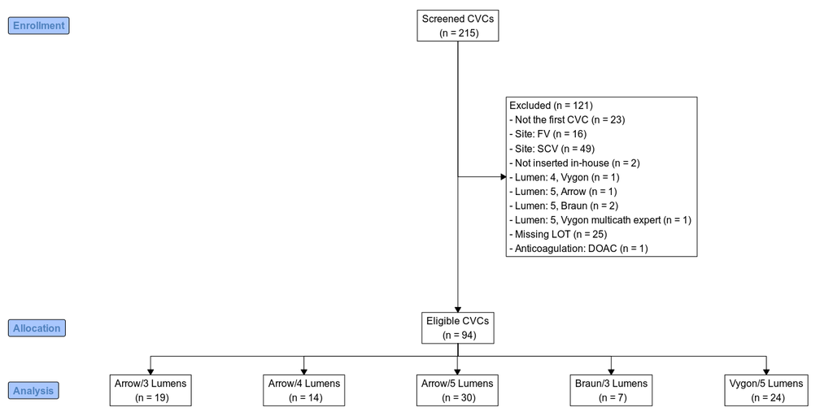

Figure 1: CONSORT diagram: the flowchart shows the inclusion and exclusion criteria. CVC, central venous catheter; DOAC, direct oral anticoagulants; FV, femoral vein; SCV, subclavian vein.

## Survival plots

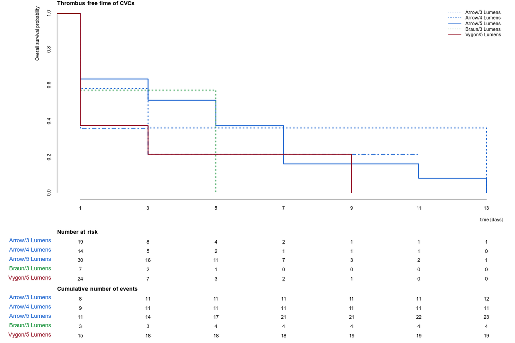

Figure 2: Survival plot showing CRT-free time for all central venous catheters analyzed. Confidence intervals overlap and have not been drawn for ease of visualization.

## Regression

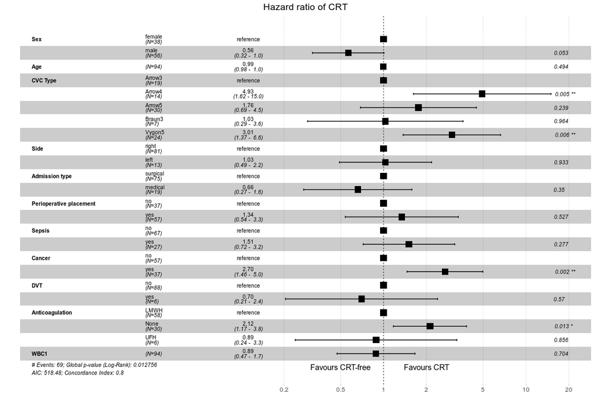

Figure 3: Hazard ratios of CRT adjusted for different covariates. CRT, catheter-related thrombosis; CVC, central venous catheter; DVT, deep vein thrombosis; LMWH, low-molecular-weight heparins; UFH, unfractionated heparin; WBC1, white blood cell count on day one.

# Incidence and onset of central venous catheter-related thrombosis in critically ill surgical patients: a prospective observational single-center study - Supplementary Information

## Penalized regression

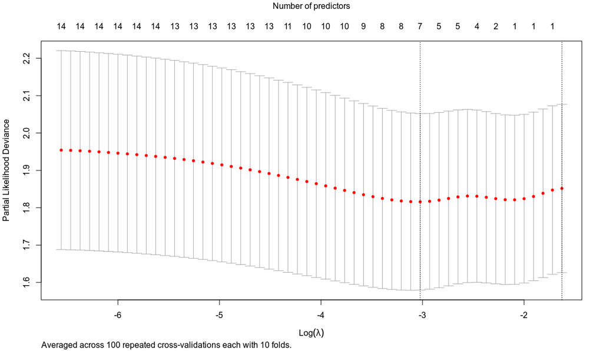

Figure 4: Cross-validation curve. Plot of cross-validation curve for least absolute shrinkage and selection operator (lasso) regression for cox proportional hazards models with 100 repeated cross-validations each with 10 folds. The dotted vertical lines mark the best model (minimal lambda) and the model with the lowest number of predictors and an error within one standard deviation (1se lambda).

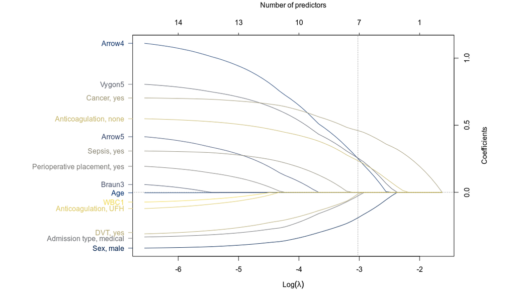

Figure 5: Coefficient profile plot. Plot of coefficient path for least absolute shrinkage and selection operator (lasso) regression for cox proportional hazards models with the minimal lambda found in a 100 repeated cross-validation each with 10 folds. The dotted vertical line marks the used logarithmized lambda of -3.02.; DVT, deep vein thrombosis; UFH, unfractionated heparins; WBC1, white blood count on day one.

Table 2: Coefficient of least absolute shrinkage and selection operator (lasso) regression for cox proportional hazards models with the minimal logarithmized lambda -3.02 found in a 100 repeated cross-validation each with 10 folds. DVT, deep vein thrombosis.

|  | Coefficient | Hazard ratio |
| --- | --- | --- |
| Sex, male | -0.190 | 0.827 |
| Arrow4 | 0.252 | 1.286 |
| Vygon5 | 0.255 | 1.291 |
| Admission type, medical | -0.027 | 0.973 |
| Cancer, yes | 0.460 | 1.584 |
| DVT, yes | -0.012 | 0.988 |
| Anticoagulation, none | 0.235 | 1.265 |

## Proportional hazards assumption

Table 3: Chi-square independence test between scaled Schoenfeld residuals and time for each covariate (as implemented by `cox.zph` in the *survival* package). CVC, central venous catheters; DF, degree of freedom; DVT, deep vein thrombosis; WBC1, white blood count on day one.

|  | Chi-square | DF | *p*-value |
| --- | --- | --- | --- |
| Sex | 0.13 | 1 | 0.72 |
| Age | 0.54 | 1 | 0.46 |
| CVC Type | 0.94 | 4 | 0.92 |
| Side | 0.04 | 1 | 0.84 |
| Admission type | 0.21 | 1 | 0.64 |
| Perioperative placement | 0.28 | 1 | 0.60 |
| Sepsis | 0.06 | 1 | 0.80 |
| Cancer | 0.89 | 1 | 0.34 |
| DVT | 0.03 | 1 | 0.86 |
| Anticoagulation | 0.67 | 2 | 0.72 |
| WBC1 | 0.93 | 1 | 0.33 |
| GLOBAL | 13.31 | 15 | 0.58 |

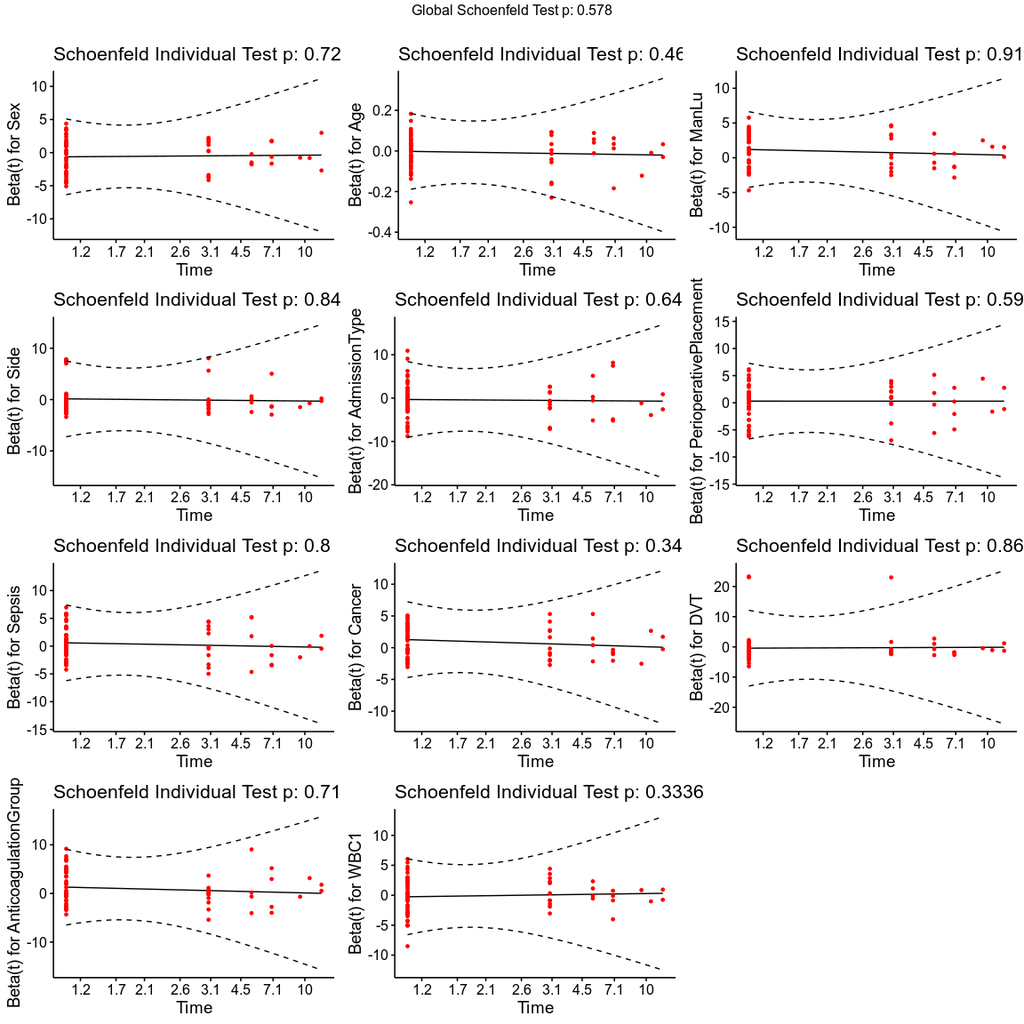

Figure 6: Scaled Schoenfeld residuals over transformed time for each covariate. Depicted *p*-values were calculated applying chi-square independence test. CVC, central venous catheters; DVT, deep vein thrombosis; WBC1, white blood count on day one.

## LOT numbers

Table 4: LOT and part numbers of examined central venous catheters. EX, Excluded; LM, Lumens; MF, Manufacturer; PN, part number.

| Id | MF | Type | LM | LOT | PN | EX |
| --- | --- | --- | --- | --- | --- | --- |
| 1 | Arrow | CVC 9.5FR | 5 | 71F22A1513 | DE-15955-S | yes |
| 2 | Arrow | NA | 5 | NA | NA | yes |
| 3 | Braun | NA | 3 | NA | NA | yes |
| 4 | Arrow | CVC 9.5FR | 5 | 71F22B0412 | DE-15955-S | no |
| 5 | Arrow | Arrowg+ard Blue | 4 | 71F21M0946 | DE-25854-S | yes |
| 6 | Vygon | multicath | 5 | 030621GH | 159.270 | no |
| 7 | Braun | Certofix protect Trio V 720-EU/SA | 3 | 21K13A8551 | 4163214P-07 | no |
| 8 | Arrow | CVC | 3 | 71F21L1114 | DE-15703-S | no |
| 9 | Vygon | multicath | 5 | 090620GA | 159.272 | no |
| 10 | Vygon | NA | 5 | NA | NA | yes |
| 11 | Arrow | CVC | 3 | 71F21H1356 | EU-15703-CVT | no |
| 12 | Arrow | CVC 9.5FR | 5 | 71F22B0412 | DE-15955-S | yes |
| 13 | Vygon | multicath | 5 | 150321GH | 159.270 | yes |
| 14 | Arrow | CVC | 5 | 71F21M0036 | EU-15955-N | yes |
| 15 | Arrow | Arrowg+ard Blue | 4 | 71F21K0421 | DE-25854-S | yes |
| 16 | Arrow | Arrowg+ard Blue | 4 | 71F21K0421 | DE-25854-S | yes |
| 17 | Vygon | NA | 5 | NA | NA | yes |
| 18 | Arrow | NA | 3 | NA | NA | yes |
| 19 | Vygon | NA | 5 | NA | NA | yes |
| 20 | Arrow | CVC 9.5FR | 5 | 71F22A1513 | DE-15955-S | yes |
| 21 | Arrow | Arrowg+ard Blue | 4 | 71F21M0946 | DE-25854-S | no |
| 22 | Vygon | multicath | 5 | 090620GA | 159.272 | no |
| 23 | Arrow | NA | 5 | NA | NA | yes |
| 24 | Arrow | CVC 9.5FR | 5 | 71F22B0412 | DE-15955-S | yes |
| 25 | Braun | NA | 3 | NA | NA | yes |
| 26 | Braun | Certofix protect Trio V 720-EU/SA | 3 | 21K13A8551 | 4163214P-07 | no |
| 27 | Vygon | multicath | 5 | 090620GA | 159.272 | no |
| 28 | Vygon | multicath | 7 | 030321GJ | 170.370 | yes |
| 29 | Arrow | CVC 9.5FR | 5 | 71F22B0412 | DE-15955-S | no |
| 30 | Arrow | CVC | 3 | 71F21M0750 | DE-15703-S | no |

[output cut: 185 more lines]

## Catheter-related thrombosis size over time

### Catheter-related thrombosis height

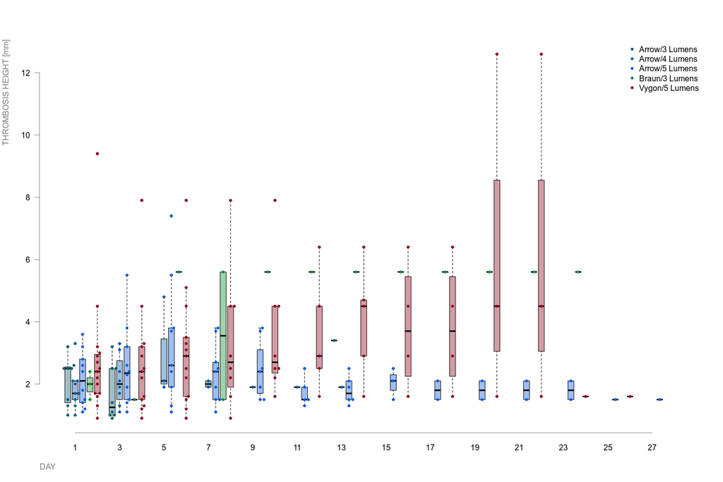

Figure 7: Boxplots of catheter-related thrombosis height over time.

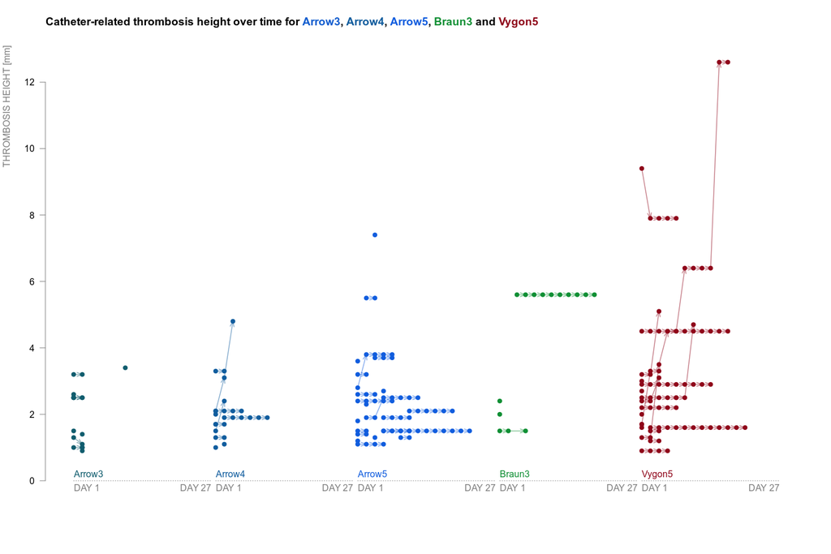

Figure 8: Catheter-related thrombosis height over time.

### Catheter-related thrombosis width

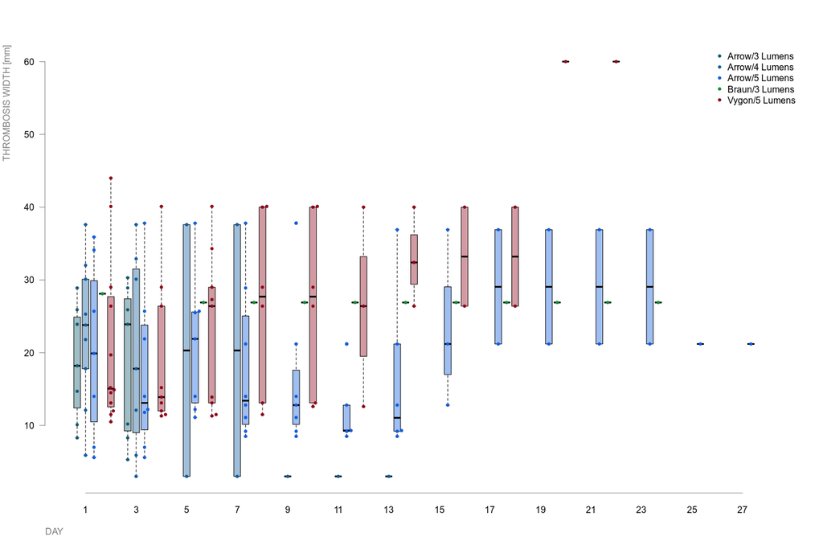

Figure 9: Boxplots of catheter-related thrombosis width over time.

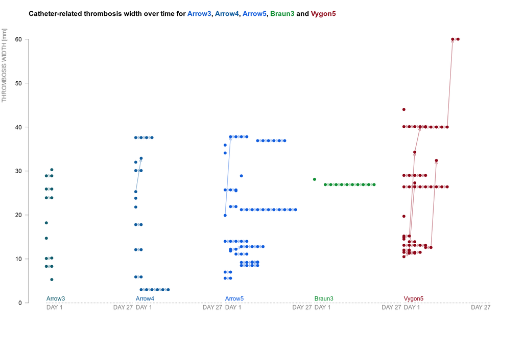

Figure 10: Catheter-related thrombosis width over time.

## Comparison CRT-free time

### Comparison CRT-free time Arrow5 vs. Vygon5

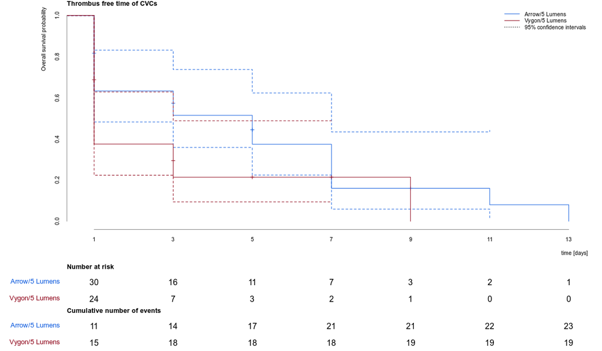

Figure 11: Survival plot showing CRT-free time for five-lumen central venous catheters.

### Comparison CRT-free time Arrow4 vs. Arrow5

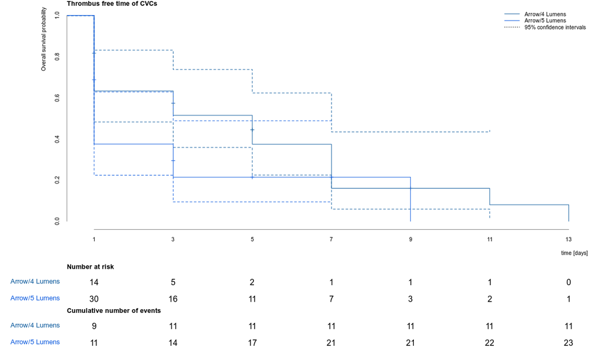

Figure 12: Survival plot showing CRT-free time for four- and five-lumen central venous catheters.

## Hazard ratios

Table 5: Hazard ratios of CRT using all available variables but with a reduced sample size of N = 57 central venous catheters due to missing values.

| **Characteristic** | **HR** **(95 % CI)**<sup>1</sup> | **p-value** |
| --- | --- | --- |
| Sex |  |  |
| female | — |  |
| male | 0.33 (0.08 to 1.38) | 0.13 |
| Age | 0.98 (0.94 to 1.02) | 0.40 |
| BMI | 0.99 (0.91 to 1.08) | 0.90 |
| Type (Manufacturer/Lumens) |  |  |
| Arrow3 | — |  |
| Arrow4 | 20.7 (2.03 to 212) | 0.011 |
| Arrow5 | 2.50 (0.34 to 18.5) | 0.37 |
| Braun3 | 0.19 (0.01 to 5.59) | 0.33 |
| Vygon5 | 7.98 (1.14 to 56.0) | 0.037 |
| Side |  |  |
| right | — |  |
| left | 0.86 (0.17 to 4.40) | 0.86 |
| Admission type |  |  |
| surgical | — |  |
| medical | 1.39 (0.30 to 6.46) | 0.68 |
| Placement in the OR |  |  |
| no | — |  |
| yes | 0.46 (0.05 to 4.36) | 0.49 |
| Incision |  |  |
| no | — |  |
| yes | 0.68 (0.20 to 2.28) | 0.53 |
| More than one insertion attempt |  |  |
| 1 | — |  |
| >1 | 0.45 (0.11 to 1.88) | 0.27 |
| Experience (number of CVCs in the past) |  |  |
| <25 | — |  |
| 25-50 | 0.22 (0.04 to 1.19) | 0.078 |
| >50 | 0.43 (0.11 to 1.78) | 0.25 |
| Specialty |  |  |
| general surgery | — |  |
| gynecology | 4.49 (0.38 to 52.5) | 0.23 |
| medical | 0.04 (0.00 to 0.93) | 0.045 |
| neurology | 0.03 (0.00 to 1.40) | 0.073 |
| neurosurgery | 0.14 (0.02 to 1.05) | 0.056 |
| orthopedics | 0.05 (0.00 to 1.19) | 0.064 |
| thoracic surgery |  |  |
| trauma surgery | 8.13 (0.21 to 320) | 0.26 |
| urology | 0.17 (0.01 to 2.64) | 0.21 |
| vascular surgery | 3.03 (0.22 to 42.7) | 0.41 |
| Sepsis |  |  |
| no | — |  |
| yes | 3.96 (0.65 to 24.0) | 0.13 |
| Cancer |  |  |
| no | — |  |
| yes | 5.94 (1.51 to 23.3) | 0.011 |
| History of vein thrombosis |  |  |
| no | — |  |
| yes | 0.19 (0.02 to 1.89) | 0.16 |
| Type of anticoagulation drug |  |  |
| LMWH | — |  |
| None | 1.98 (0.51 to 7.63) | 0.32 |
| UFH | 0.49 (0.04 to 6.43) | 0.59 |
| WBC day 1 [Gpt/L] | 0.33 (0.07 to 1.56) | 0.16 |
| D-dimer day 1 [mg/L] | 1.05 (0.47 to 2.36) | 0.91 |
| CRP day 1 [mg/L] | 0.92 (0.45 to 1.91) | 0.83 |

<sup>1</sup> HR = Hazard Ratio, CI = Confidence Interval

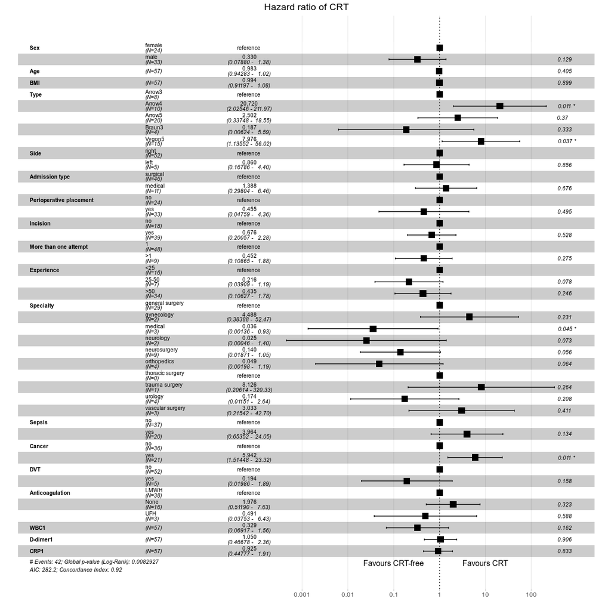

Figure 13: Hazard ratios for all available variables but with reduced sample size. CRP1: C-reactive peptide on day one; D-dimer1: d-dimer on day one; DVT, deep vein thrombosis; LMWH, low-molecular-weight heparins; UFH, unfractionated heparin; WBC1, white blood cell count on day one.

Table 6: Hazard ratios for Cox regression of CRT for all analyzed central venous catheters (N = 94).

| **Characteristic** | **HR** **(95 % CI)**<sup>1</sup> | **p-value** |
| --- | --- | --- |
| Sex |  |  |
| female | — |  |
| male | 0.56 (0.32 to 1.01) | 0.053 |
| Age | 0.99 (0.98 to 1.01) | 0.49 |
| Type (Manufacturer/Lumens) |  |  |
| Arrow3 | — |  |
| Arrow4 | 4.93 (1.62 to 15.0) | 0.005 |
| Arrow5 | 1.76 (0.69 to 4.48) | 0.24 |
| Braun3 | 1.03 (0.29 to 3.61) | 0.96 |
| Vygon5 | 3.01 (1.37 to 6.63) | 0.006 |
| Side |  |  |
| right | — |  |
| left | 1.03 (0.49 to 2.17) | 0.93 |
| Admission type |  |  |
| surgical | — |  |
| medical | 0.66 (0.27 to 1.58) | 0.35 |
| Placement in the OR |  |  |
| no | — |  |
| yes | 1.34 (0.54 to 3.35) | 0.53 |
| Sepsis |  |  |
| no | — |  |
| yes | 1.51 (0.72 to 3.16) | 0.28 |
| Cancer |  |  |
| no | — |  |
| yes | 2.70 (1.46 to 4.98) | 0.002 |
| History of vein thrombosis |  |  |
| no | — |  |
| yes | 0.70 (0.21 to 2.39) | 0.57 |
| Type of anticoagulation drug |  |  |
| LMWH | — |  |
| None | 2.12 (1.17 to 3.82) | 0.013 |
| UFH | 0.89 (0.24 to 3.27) | 0.86 |
| WBC day 1 [Gpt/L] | 0.89 (0.47 to 1.66) | 0.70 |

<sup>1</sup> HR = Hazard Ratio, CI = Confidence Interval

Table 7: Hazard ratios of CRT assuming that central venous catheters with missing LOTs were of each manufacturer’s main type. Sample size of N = 119.

| **Characteristic** | **HR** **(95 % CI)**<sup>1</sup> | **p-value** |
| --- | --- | --- |
| Sex |  |  |
| female | — |  |
| male | 0.65 (0.41 to 1.02) | 0.060 |
| Age | 1.0 (0.98 to 1.01) | 0.53 |
| Type (Manufacturer/Lumens) |  |  |
| Arrow3 | — |  |
| Arrow4 | 2.83 (1.02 to 7.82) | 0.045 |
| Arrow5 | 1.17 (0.49 to 2.79) | 0.72 |
| Braun3 | 1.34 (0.50 to 3.59) | 0.56 |
| Vygon5 | 2.00 (1.03 to 3.86) | 0.040 |
| Side |  |  |
| right | — |  |
| left | 1.14 (0.61 to 2.13) | 0.69 |
| Admission type |  |  |
| surgical | — |  |
| medical | 0.96 (0.46 to 2.00) | 0.92 |
| Placement in the OR |  |  |
| no | — |  |
| yes | 1.17 (0.51 to 2.66) | 0.71 |
| Sepsis |  |  |
| no | — |  |
| yes | 0.87 (0.47 to 1.61) | 0.67 |
| Cancer |  |  |
| no | — |  |
| yes | 2.07 (1.27 to 3.37) | 0.004 |
| History of vein thrombosis |  |  |
| no | — |  |
| yes | 0.84 (0.29 to 2.44) | 0.76 |
| Type of anticoagulation drug |  |  |
| LMWH | — |  |
| None | 1.41 (0.84 to 2.37) | 0.19 |
| UFH | 0.79 (0.27 to 2.34) | 0.67 |
| WBC day 1 [Gpt/L] | 1.02 (0.98 to 1.05) | 0.42 |

<sup>1</sup> HR = Hazard Ratio, CI = Confidence Interval

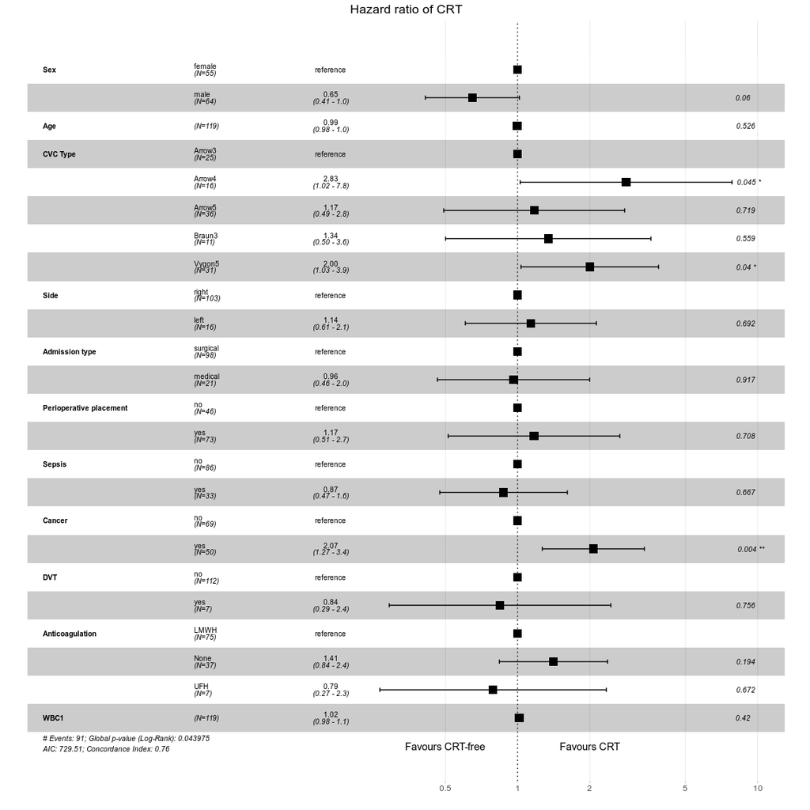

Figure 14: Hazard ratios of CRT for all central venous catheters assuming that missing LOTs were of each manufacturer’s main type. DVT, deep vein thrombosis; LMWH, low-molecular-weight heparins; UFH, unfractionated heparin; WBC1, white blood cell count on day one.

## Git commit hash

```
## [1] "Git commit revision: 5df470d9a2c2cf467aa45287ddfc567aed218e9a"
```